# Building ACT

Mono Wireless Inc.

# Building ACT

The application program written in the MWX library is called ACT. The first step is to build and write it.

- About the build folder structure
- About the build script
- About building with VS Code

This page describes several methods of building, all of which ultimately involve running the make command. Please refer to the Makefile description for details.

## About the build folder structure

Open the folder `MWSDK_ROOT` (e.g. `C:\MWSDK`) where you have installed the MWSDK. It has the following structure

```
MWSDK_ROOT
  |
  +-ChipLib      : Semiconductor library
  +-License      : Software License Agreement
  +-MkFiles      : makefile
  +-Tools        : A set of tools such as compilers
  +-TWENET       : TWENET/MWX library
  +-Act_samples  : Sample codes of ACT
  ...
```

```
Act_samples
  |
  +-BRD_APPTWELITE    : ACT for boards with the same configuration as App_TweLite
  +-PAL_AMB           : ACT for environmental sense PAL
  +-PAL_MAG           : ACT for open-close PAL
  +-PAL_MOT           : ACT for motion PAL
  ..
  +-Parent-MONOSTICK  : ACT for parent device (for MONOSTICK)
  +-PingPong          : ACT for transmit and receive like Ping Pong
  +-PulseCounter      : ACT using a pulse counter
  +-act0              : Scratching ACT
```

These acts are simple examples to help you write your own MWX library, but many of them have the following features

- Obtaining sensor values
- After obtaining the sensor value, send a wireless packet to the master
- Sleeps for a period of time (or waits for an interrupt) after transmission is complete

When trying to get it to work in practice, try the following combinations:

| Parents | Child | Remark |
| --- | --- | --- |
| BRD_APPTWELITE | BRD_APPTWELITE | The parent device is started with the M1 pin low (GND level). In normal mode (always running), you can see it works like App_TweLite. |
| PingPong | PingPong | The system works with two children. When one of them sends a ping packet, the other sends a pong packet back. |
| Parent-MONOSTICK | Other | You can check the transmission of packets of the act for the child machine. |

Now let’s take a look inside the PingPong folder from within ACT.

You can also build other acts in `Act_samples`. In this case, the folder and file names should be read differently.

```
Act_samples
  +-PingPong
    +-PingPong.cpp   : ACT code
    +-build          : build folder
    +-.vscode        : setting files for VS Code
```

You must have a `.cpp` file with the same name as the folder directly under the folder.

If it is a small act, you can write it in this `.cpp` file. If you have a larger act, you can build it in multiple files by referring to the Makefile description.

The ACT file PingPong.cpp is located directly under the PingPong folder. If you change the name of the folder, make sure to rename the .cpp file to the same name as the folder.

Next, open the build folder.

```
Act_samples
  +-PingPong
    +-build
      +-Makefile        : makefile
      +-build-BLUE.cmd  : build script for TWELITE BLUE
      +-build-RED.cmd   : build script for TWELITE RED
      +-build-clean.cmd : clean up obj_* files
```

It contains the scripts and Makefiles needed for the build.

## Build Script (Windows 10)

On macOS and Linux, you can build using VS Code or the command line.

Build scripts are suitable for completed ACTs, sample offerings, etc., which are less prone to errors.

The following is a script (batch file) for Windows 10.

| Name | Remark |
| --- | --- |
| build-BLUE.cmd | for TWELITE BLUE |
| build-RED.cmd | for TWELITE RED |

After execution, a `bin` file will be created and will contain `PingPong_BLUE_???.bin` or `PingPong_RED_???.bin`. The `???`will be replaced by the version number or library version letter.

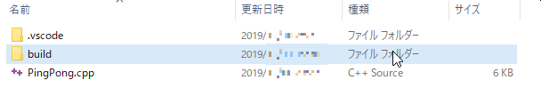

PingPong アクトのフォルダを開く

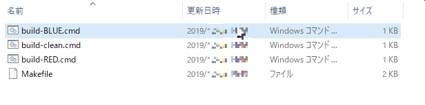

Double-click on build-BLUE.cmd (Run)

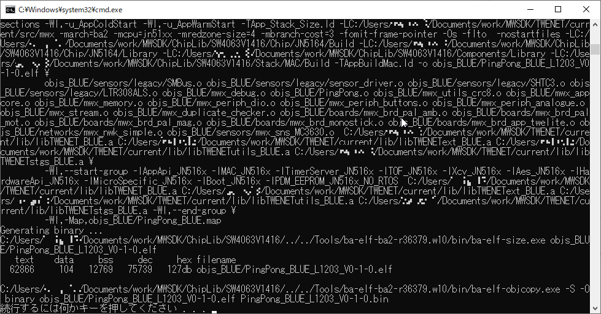

ビルド結果

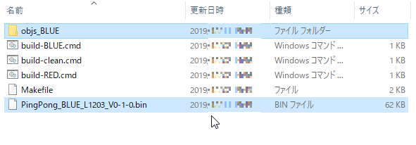

A BIN file (PingPong_BLUE_L1203_V0-1-0.bin) has been created.

If a BIN file is created, the build is successful.

The `objs_BLUE` folder is an intermediate file generated during the build process. You can delete it if you wish.

In order to speed up the build, we have set up a parallel build option. This makes it difficult to see the error messages in case of errors.

If you want to see the error messages efficiently, we recommend using a development tool such as VS Code.

### Clean (remove intermediate files)

If you run `build-clean.cmd`, it will clean folders starting with `objs_`, but not BIN files.

If the build does not work, check the error messages first; often the cause of the error can be easily identified from a message on a line containing the string error.

Delete the intermediate files in the `objs_?` folder and try running it again. (All operations, including `make clean`, will fail if there are any intermediate files left over from builds in other environments).

## Build on command line (Linux/macOS)

Additional information about building in the command line environment.

A working knowledge of the command line (bash) is required.

Depending on the OS environment, security warnings may appear when running each executable program. It is necessary to configure the settings to suppress the warning. (**Please consult with yourself or your system administrator to determine if you wish to run the program with the warning suppressed.**)

To build by command line, run `make` in a window where `bash` (Bourne-again shell) is running. Make sure that the environment variable `MWSDK_ROOT` is set correctly beforehand. For example, if you install to `C:/MWSDK`, set `~/.profile` as follows.

```bash
MWSDK_ROOT=/mnt/c/MWSDK
export MWSDK_ROOT
```

Run `make` from the command line (bash). If `make` is not available, you need to install a package.

```bash
$ make

Command 'make' not found, but can be installed with:

sudo apt install make
sudo apt install make-guile

$ sudo apt install make
...
```

- On Linux/WSL environments, install the `make` or `build-essential` package.
- In the macOS environment, install Command Line Tools in Xcode.

A build should look like this:

```
$ cd $MWSDK_ROOT
$ cd Act_samples/PingPong/build
$ pwd
/mnt/c/MWSDK/Act_samples/PingPong/build

$ ls
... View file list

$ rm -rfv objs_*
... Delete intermediate files just in case

$ make TWELITE=BLUE
... Normal build for BLUE

$ make -j8 TWELITE=BLUE
... Parallel build for BLUE (8 processes simultaneously)
```

### About intermediate files

When the build is done, the `objs_???` folder is created and an intermediate file is created in it. This file is dependent on the environment in which it was compiled, so if any files from other environments are left, make will fail and the build will fail.

If `make` fails, directly **delete** the `objs_???` folder.

### Example commands

See the Makefile description for more details.

| Example | Remark |
| --- | --- |
| `make TWELITE=BLUE` | build for TWELITE BLUE |
| `make TWELITE=RED` | build for TWELITE RED |
| `make cleanall` | Delete intermediate files |

## About building with VS Code

TWELITE STAGE is recommended for builds.

The VS Code definition files for the sample projects supplied with the MWSDK are implemented as far as possible, but some definitions could be incomplete.

Depending on the OS environment, security warnings may appear when running each executable program. It is necessary to configure the settings to suppress the warning. (Please consult with yourself or your system administrator to determine if you wish to **run the program with the warning suppressed.**)

In VS Code, you can either open the workspace file directly under the `Act_samples` folder, or open the act folder under `Act_samples`.

In the example below, a workspace is opened with an example screen of the English interface.

Open a workspace and select `[Terminal>Run Task...]`.

[figure not shown]

List of build tasks

Select the type of TWELITE radio module (BLUE/RED) and the act name to build. In the example below we have selected Build for TWELITE BLUE PingPong (for TWELITE BLUE/PingPong act). The build will start immediately after selection.

[figure not shown]

Selecting a build task

The progress of the build is shown in the TERMINAL section at the bottom of the screen.

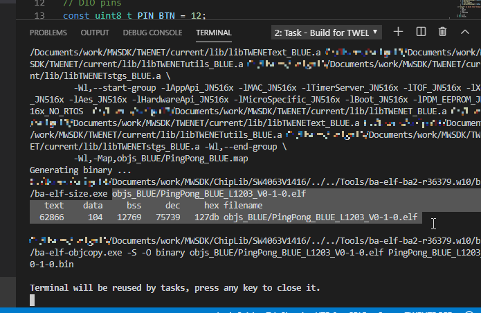

Build progress

If the build is successful, you will see a message about the creation of the `.elf` file, along with its size information (`text data bss dec hex filename`), as shown in the highlighted part of the screenshot above.

Also, a BIN file (in the above example, `PingPong_BLUE_???.bin`) file should be created under the `build` folder. Please check it.

The build definition adds a definition to convert folder names (e.g. `/c/User/...`) that do not conform to the Windows 10 file system (e.g. `C:/User/...`).

The conversion is not complete, but you can extract the filename and line number of the error from the compilation message.

The execution command in `.vscode/tasks.json` is `sh -c "make ... | sed -E -e s#..."` to rewrite the string of the drive name equivalent in the output message.

```
...
"windows": {
    "command": "sh",
    "args": [
        "-c", "make TWELITE=BLUE 2>&1 | sed -E -e s#\\(/mnt\\)?/\\([a-zA-Z]\\)/#\\\\\\2:/#g"
    ],
```

If the build does not work, **check the error messages first**; it is often easy to identify the cause of an error from a message on a line containing the string error.。

To be sure, clean (remove intermediate files in the `objs_???` folder) and rerun the build to be sure. (All operations, including `make clean`, will fail if there are intermediate files left over from builds in other environments).

## About WSL

WSL ([Windows Subsystem for Linux](https://docs.microsoft.com/en-us/windows/wsl/about)) is a Linux environment that runs as a subsystem of Windows 10.

On Windows 10, WSL (Windows Subsystem for Linux) is not required to build acts with MWSDK unless there is a specific reason to do so; only those who are already familiar with WSL and want to use it specifically should read this section. This section does not cover how to install or use WSL.

### MWSDK2020_05 .. 2020_10

You will find both Windows 10 and Linux executables under `MWSDK/Tools/ba-elf-ba2-r36379.w10`, run WSL and set the environment variable `MWSDK_ROOT` appropriately.

For example, for `C:\Work\MWSTAGE\MWSDK`, set the following:

```
$ export MWSDK_ROOT=/mnt/c/Work/MWSTAGE/MWSDK
```

### MWSDK2020_12

The TWELITE STAGE SDK package does not include an executable for WSL.

Store the complete set of tools in a folder named `MWSTAGE/Tools/ba-elf-ba2-r36379.wsl`. It is easier to use `MWSDK/Tools/ba-elf-ba2-r36379.w10` in MWSDK2020_10.

### Select a toolツールの選択

```
# Configure for WSL (Windows Subsystem Linux)
ifneq ($(origin WSLENV),undefined)
$(info !!!WSL environment, use Linux toolchain instead.)
TOOLCHAIN_PATH = ba-elf-ba2-r36379.wsl
endif
```